# Tutorial for knowledge classification from raw text

Huang Tian-Yuan (Hope)

This tutorial gives an example of how to use `akc` package to carry out automatic knowledge classification based on raw text. First, load the packages we need.

```r
library(akc)
library(dplyr)
```

## Inspect the data

In the dataset, we have the ID, title, keyword and abstract of documents. We are going to use the keyword as the dictionary to extract keywords from the abstract.

```r
bibli_data_table
```

```
#> # A tibble: 1,448 × 4
#>       id title                                                  keyword abstract
#>    <int> <chr>                                                  <chr>   <chr>
#>  1     1 Keeping the doors open in an age of austerity? Qualit… Auster… "Englis…
#>  2     2 Comparison of Slovenian and Korean library laws        Compar… "This p…
#>  3     3 Analysis of the factors affecting volunteering, satis… Contin… "This s…
#>  4     4 Redefining Library and Information Science education … Curric… "The pu…
#>  5     5 Can in-house use data of print collections shed new l… Check-… "Librar…
#>  6     6 Practices of community representatives in exploiting … Commun… "The pu…
#>  7     7 Exploring Becoming, Doing, and Relating within the in… Librar… "Profes…
#>  8     8 Predictors of burnout in public library employees      Emotio… "Work s…
#>  9     9 The Roma and documentary film: Considerations for col… Academ… "This p…
#> 10    10 Mediation effect of knowledge management on the relat… Job pe… "This p…
#> # ℹ 1,438 more rows
```

## Get the dictionary from keyword field

`keyword_clean` is designed to split the keywords and removed pure numbers and contents in the parentheses. All letters would be converted to lower case. Details see the help of `keyword_clean`, use “?keyword_clean”. After cleaning, we’ll use these keywords to establish a dictionary.

```r
bibli_data_table %>%
  keyword_clean() %>%
  pull(keyword) %>%
  make_dict() -> my_dict
```

## Extract keywords from abstract

Using `keyword_extract` to extract keywords from the abstract. Here, we also exclude the stop words using the “stopword” parameter.

```r
# get stop words from `tidytext` package
tidytext::stop_words %>%
    pull(word) %>%
    unique() -> my_stopword

bibli_data_table %>%
    keyword_extract(id = "id",text = "abstract",
    dict = my_dict,stopword = my_stopword) -> extracted_keywords
```

## Merge keywords with same meanings

While this process has consider lots of factors, such as stemming, lemmatizing, etc. Here I’ll provide a easy implementation. For advanced usage, use “?keyword_merge” to find out.

```r
extracted_keywords %>%
  keyword_merge() -> merged_keywords
```

## Divide keywords into groups (automatic classification)

This process will construct a keyword co-occurrence network and use community detection to group the keywords automatically. You can use “top” or “min_freq” to control how many keywords should be included in the network. “top” means how many keywords with largest frequency should be included. “min_freq” means the included keywords should emerge at least how many times. Default uses `top = 200` and `min_freq = 1`.

```r
merged_keywords %>%
  keyword_group() -> grouped_keywords
```

## Get the grouped table

Getting the result as a table could be easy by:

```r
grouped_keywords %>%
  as_tibble()
```

[output not shown]

If you only wants the top keywords to be displayed, `keyword_table` provides another relatively formal table:

```r
grouped_keywords %>%
  keyword_table()
```

```
#> # A tibble: 2 × 2
#>   Group `Keywords (TOP 10)`
#>   <int> <chr>
#> 1     1 library (1583); research (589); information (583); data (437); universi…
#> 2     2 academic (351); collection (283); development (254); academic libraries…
```

In such implementation, only two groups are found. You can specify the number of top keywords using “top” parameter.

## Visualization of the network

Currently, `keyword_vis`,`keyword_network` and `keyword_cloud` could all be used to draw plots for the network, but in differnt forms. Let’s try to draw a word cloud first:

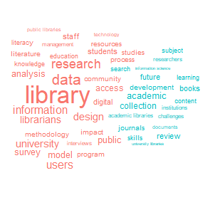

```r
grouped_keywords %>%
  keyword_cloud()
```

To get the word cloud of one group,use:

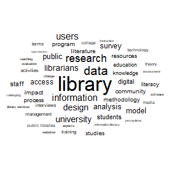

```r
grouped_keywords %>%
  keyword_cloud(group_no = 1)
```

If you want to draw a network, use `keyword_network`:

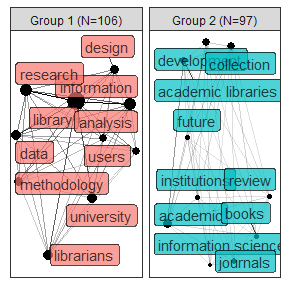

```r
grouped_keywords %>%
  keyword_network()
```

In the plot, “N=106” means altogether there are 106 keywords in the group, though only the top 10 by frequency are showed in the graph. If you only want to visualize the second group and display 20 nodes, try:

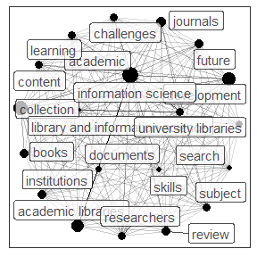

```r
grouped_keywords %>%
  keyword_network(group_no = 2,max_nodes = 20)
```

Have fun playing with akc!